Predicting Survival of a person on Titanic  
by: Nauman Akram

```r
## Necessary librarys to perform eda
library(ggplot2)
library(dplyr)
#loading dataset
dataset <- read.csv("train.csv", stringsAsFactors = FALSE)
str(dataset)
```

```
## 'data.frame':    891 obs. of  12 variables:
##  $ PassengerId: int  1 2 3 4 5 6 7 8 9 10 ...
##  $ Survived   : int  0 1 1 1 0 0 0 0 1 1 ...
##  $ Pclass     : int  3 1 3 1 3 3 1 3 3 2 ...
##  $ Name       : chr  "Braund, Mr. Owen Harris" "Cumings, Mrs. John Bradley (Florence Briggs Thayer)" "Heikkinen, Miss. Laina" "Futrelle, Mrs. Jacques Heath (Lily May Peel)" ...
##  $ Sex        : chr  "male" "female" "female" "female" ...
##  $ Age        : num  22 38 26 35 35 NA 54 2 27 14 ...
##  $ SibSp      : int  1 1 0 1 0 0 0 3 0 1 ...
##  $ Parch      : int  0 0 0 0 0 0 0 1 2 0 ...
##  $ Ticket     : chr  "A/5 21171" "PC 17599" "STON/O2. 3101282" "113803" ...
##  $ Fare       : num  7.25 71.28 7.92 53.1 8.05 ...
##  $ Cabin      : chr  "" "C85" "" "C123" ...
##  $ Embarked   : chr  "S" "C" "S" "S" ...
```

About Data: The dataset consist of above fields and my goal is to predict whether someone(test) will survive titanic disaster or not

```r
#checking null values
colSums(is.na(dataset))
```

```
## PassengerId    Survived      Pclass        Name         Sex         Age
##           0           0           0           0           0         177
##       SibSp       Parch      Ticket        Fare       Cabin    Embarked
##           0           0           0           0           0           0
```

```r
colSums(dataset=="")
```

```
## PassengerId    Survived      Pclass        Name         Sex         Age
##           0           0           0           0           0          NA
##       SibSp       Parch      Ticket        Fare       Cabin    Embarked
##           0           0           0           0         687           2
```

After checking nulls in the dataset for embarked had only two missing fields can be imputed by any of its possibe values to remove missing data.

```r
dataset$Embarked[dataset$Embarked==""]="C"

# Checking how many features can be used as categorical (factors)
apply(dataset,2, function(x) length(unique(x)))
```

```
## PassengerId    Survived      Pclass        Name         Sex         Age
##         891           2           3         891           2          89
##       SibSp       Parch      Ticket        Fare       Cabin    Embarked
##           7           7         681         248         148           3
```

Survived is our label/class for predicting, remaining are our features of dataset. Here, I will be coverting to factors so that I can you numeric values for my model

```r
cols<-c("Pclass","Sex","Embarked")
for (i in cols){
  dataset[,i] <- as.factor(dataset[,i])
}

str(dataset)
```

```
## 'data.frame':    891 obs. of  12 variables:
##  $ PassengerId: int  1 2 3 4 5 6 7 8 9 10 ...
##  $ Survived   : int  0 1 1 1 0 0 0 0 1 1 ...
##  $ Pclass     : Factor w/ 3 levels "1","2","3": 3 1 3 1 3 3 1 3 3 2 ...
##  $ Name       : chr  "Braund, Mr. Owen Harris" "Cumings, Mrs. John Bradley (Florence Briggs Thayer)" "Heikkinen, Miss. Laina" "Futrelle, Mrs. Jacques Heath (Lily May Peel)" ...
##  $ Sex        : Factor w/ 2 levels "female","male": 2 1 1 1 2 2 2 2 1 1 ...
##  $ Age        : num  22 38 26 35 35 NA 54 2 27 14 ...
##  $ SibSp      : int  1 1 0 1 0 0 0 3 0 1 ...
##  $ Parch      : int  0 0 0 0 0 0 0 1 2 0 ...
##  $ Ticket     : chr  "A/5 21171" "PC 17599" "STON/O2. 3101282" "113803" ...
##  $ Fare       : num  7.25 71.28 7.92 53.1 8.05 ...
##  $ Cabin      : chr  "" "C85" "" "C123" ...
##  $ Embarked   : Factor w/ 3 levels "C","Q","S": 3 1 3 3 3 2 3 3 3 1 ...
```

dataset Name contatins different titles that could be usefull knowing who was male, female, officer, or if one was married or not, so I removed titles from name through pattern matching

```r
dataset$Title <- gsub('(.*, )|(\\..*)', '', dataset$Name)
dataset$Title[dataset$Title == 'Mlle']<- 'Miss'
dataset$Title[dataset$Title == 'Ms']<- 'Miss'
dataset$Title[dataset$Title == 'Mme']<- 'Mrs'
dataset$Title[dataset$Title == 'Lady']<- 'Miss'
dataset$Title[dataset$Title == 'Dona']<- 'Miss'
officer<- c('Capt','Col','Don','Dr','Jonkheer','Major','Rev','Sir','the Countess')
dataset$Title[dataset$Title %in% officer]<-'Officer'

dataset$Title<- as.factor(dataset$Title)

str(dataset)
```

```
## 'data.frame':    891 obs. of  13 variables:
##  $ PassengerId: int  1 2 3 4 5 6 7 8 9 10 ...
##  $ Survived   : int  0 1 1 1 0 0 0 0 1 1 ...
##  $ Pclass     : Factor w/ 3 levels "1","2","3": 3 1 3 1 3 3 1 3 3 2 ...
##  $ Name       : chr  "Braund, Mr. Owen Harris" "Cumings, Mrs. John Bradley (Florence Briggs Thayer)" "Heikkinen, Miss. Laina" "Futrelle, Mrs. Jacques Heath (Lily May Peel)" ...
##  $ Sex        : Factor w/ 2 levels "female","male": 2 1 1 1 2 2 2 2 1 1 ...
##  $ Age        : num  22 38 26 35 35 NA 54 2 27 14 ...
##  $ SibSp      : int  1 1 0 1 0 0 0 3 0 1 ...
##  $ Parch      : int  0 0 0 0 0 0 0 1 2 0 ...
##  $ Ticket     : chr  "A/5 21171" "PC 17599" "STON/O2. 3101282" "113803" ...
##  $ Fare       : num  7.25 71.28 7.92 53.1 8.05 ...
##  $ Cabin      : chr  "" "C85" "" "C123" ...
##  $ Embarked   : Factor w/ 3 levels "C","Q","S": 3 1 3 3 3 2 3 3 3 1 ...
##  $ Title      : Factor w/ 5 levels "Master","Miss",..: 3 4 2 4 3 3 3 1 4 4 ...
```

The dataset here we can see that passengerId is just continous no., don’t add any information to predict survival, same goes for name (different charachters), ticket no. and cabins (although they could be used but there were in big numbers as indvidual cabins so using them as factors won’t do much to our feature matrix) So we select remaining features!

```r
label <- dataset[,"Survived"]
label_Survived <- dataset["Survived"]
label_Survived <- as.factor(label_Survived[,])
X <- dataset[, c("Title", "Pclass", "Sex", "Age", "SibSp", "Parch","Fare" , "Embarked")]
```

```r
colSums(is.na(X))
```

```
##    Title   Pclass      Sex      Age    SibSp    Parch     Fare Embarked
##        0        0        0      177        0        0        0        0
```

```r
colSums(X=="")
```

```
##    Title   Pclass      Sex      Age    SibSp    Parch     Fare Embarked
##        0        0        0       NA        0        0        0        0
```

After choosing features we still left with age that contains 177 null values, so I will impute avg age of female in null values(where sex is female) and avg age of male in male null values.

```r
# replacing missing values in age with mean values w.r.t to their Sex

means = aggregate(X["Age"], list(X$Sex), mean,  na.rm = T, na.action=na.pass )
means
```

```
##   Group.1      Age
## 1  female 27.91571
## 2    male 30.72664
```

As age was used as discrete no. in this dataset thats why I rounded them to get only integer part.

```r
f_mean <- round(means[1,"Age"])
m_mean <- round(means[2,"Age"])

f_mean
```

```
## [1] 28
```

```r
m_mean
```

```
## [1] 31
```

```r
tail(X,n=30)
```

```
##       Title Pclass    Sex Age SibSp Parch    Fare Embarked
## 862      Mr      2   male  21     1     0 11.5000        S
## 863     Mrs      1 female  48     0     0 25.9292        S
## 864    Miss      3 female  NA     8     2 69.5500        S
## 865      Mr      2   male  24     0     0 13.0000        S
## 866     Mrs      2 female  42     0     0 13.0000        S
## 867    Miss      2 female  27     1     0 13.8583        C
## 868      Mr      1   male  31     0     0 50.4958        S
## 869      Mr      3   male  NA     0     0  9.5000        S
## 870  Master      3   male   4     1     1 11.1333        S
## 871      Mr      3   male  26     0     0  7.8958        S
## 872     Mrs      1 female  47     1     1 52.5542        S
## 873      Mr      1   male  33     0     0  5.0000        S
## 874      Mr      3   male  47     0     0  9.0000        S
## 875     Mrs      2 female  28     1     0 24.0000        C
```

[output cut: 16 more lines]

Subtiting mean values in age

```r
for (i in which (is.na(X$Age) ))
{
  if(X[i,"Sex"]=="female")
  {
    X[i,"Age"] <- f_mean
  }
  else
  {
    X[i,"Age"] <- m_mean
  }
}
```

can be checked here

```r
tail(X, n=30)
```

```
##       Title Pclass    Sex Age SibSp Parch    Fare Embarked
## 862      Mr      2   male  21     1     0 11.5000        S
## 863     Mrs      1 female  48     0     0 25.9292        S
## 864    Miss      3 female  28     8     2 69.5500        S
## 865      Mr      2   male  24     0     0 13.0000        S
## 866     Mrs      2 female  42     0     0 13.0000        S
## 867    Miss      2 female  27     1     0 13.8583        C
## 868      Mr      1   male  31     0     0 50.4958        S
## 869      Mr      3   male  31     0     0  9.5000        S
## 870  Master      3   male   4     1     1 11.1333        S
## 871      Mr      3   male  26     0     0  7.8958        S
## 872     Mrs      1 female  47     1     1 52.5542        S
## 873      Mr      1   male  33     0     0  5.0000        S
## 874      Mr      3   male  47     0     0  9.0000        S
## 875     Mrs      2 female  28     1     0 24.0000        C
```

[output cut: 16 more lines]

confirming if any null still remains…

```r
colSums(is.na(X))
```

```
##    Title   Pclass      Sex      Age    SibSp    Parch     Fare Embarked
##        0        0        0        0        0        0        0        0
```

For factors we need to convert them to their numeric for correlation, so I made a copy in X1 before converting

```r
X1 <- data.frame(X)
X$Embarked <- as.numeric(X$Embarked)
X$Sex <- as.numeric(X$Sex)
X$Title <- as.numeric(X$Title)
X$Pclass <- as.numeric(X$Pclass)

head(X)
```

```
##   Title Pclass Sex Age SibSp Parch    Fare Embarked
## 1     3      3   2  22     1     0  7.2500        3
## 2     4      1   1  38     1     0 71.2833        1
## 3     2      3   1  26     0     0  7.9250        3
## 4     4      1   1  35     1     0 53.1000        3
## 5     3      3   2  35     0     0  8.0500        3
## 6     3      3   2  31     0     0  8.4583        2
```

```r
str(X)
```

```
## 'data.frame':    891 obs. of  8 variables:
##  $ Title   : num  3 4 2 4 3 3 3 1 4 4 ...
##  $ Pclass  : num  3 1 3 1 3 3 1 3 3 2 ...
##  $ Sex     : num  2 1 1 1 2 2 2 2 1 1 ...
##  $ Age     : num  22 38 26 35 35 31 54 2 27 14 ...
##  $ SibSp   : int  1 1 0 1 0 0 0 3 0 1 ...
##  $ Parch   : int  0 0 0 0 0 0 0 1 2 0 ...
##  $ Fare    : num  7.25 71.28 7.92 53.1 8.05 ...
##  $ Embarked: num  3 1 3 3 3 2 3 3 3 1 ...
```

```r
# pearson correleation by default method is pearson, else put method= c("spearman")
X.cor = cor(X,X)
X.cor
```

```
##                Title      Pclass        Sex         Age       SibSp
## Title     1.00000000 -0.17506135  0.0663092  0.47419978 -0.21236136
## Pclass   -0.17506135  1.00000000  0.1319005 -0.32920138  0.08308136
## Sex       0.06630920  0.13190049  1.0000000  0.10485001 -0.11463081
## Age       0.47419978 -0.32920138  0.1048500  1.00000000 -0.23705937
## SibSp    -0.21236136  0.08308136 -0.1146308 -0.23705937  1.00000000
## Parch    -0.11594499  0.01844267 -0.2454890 -0.18353633  0.41483770
## Fare     -0.01395520 -0.54949962 -0.1823328  0.08826981  0.15965104
## Embarked  0.01272364  0.17033404  0.1155133 -0.03383567  0.07065311
##                Parch        Fare    Embarked
## Title    -0.11594499 -0.01395520  0.01272364
## Pclass    0.01844267 -0.54949962  0.17033404
## Sex      -0.24548896 -0.18233283  0.11551335
## Age      -0.18353633  0.08826981 -0.03383567
## SibSp     0.41483770  0.15965104  0.07065311
## Parch     1.00000000  0.21622494  0.04232463
## Fare      0.21622494  1.00000000 -0.22930366
## Embarked  0.04232463 -0.22930366  1.00000000
```

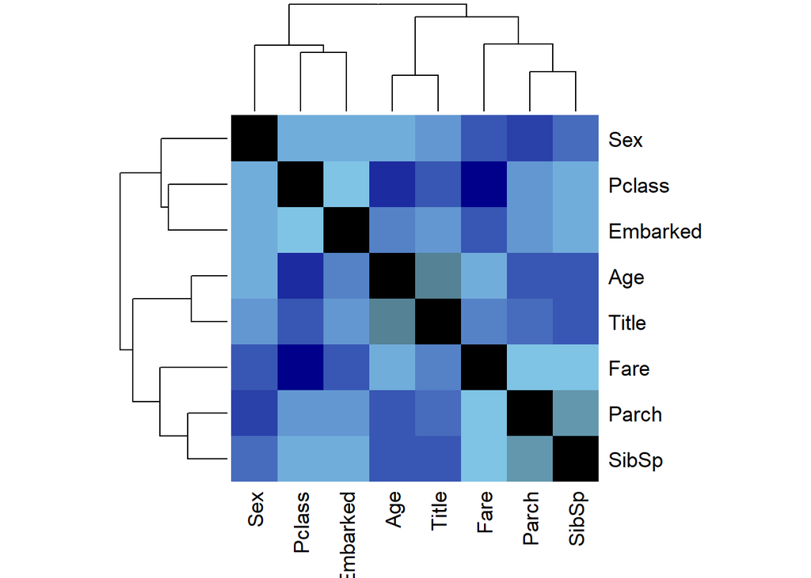

```r
palette = colorRampPalette(c("darkBlue", "SkyBlue", "Black")) (20)
heatmap(x = X.cor, col = palette, symm = TRUE)
```

Correlation of features tells the dependency of vaiables the stronger color represennts stronger relation.

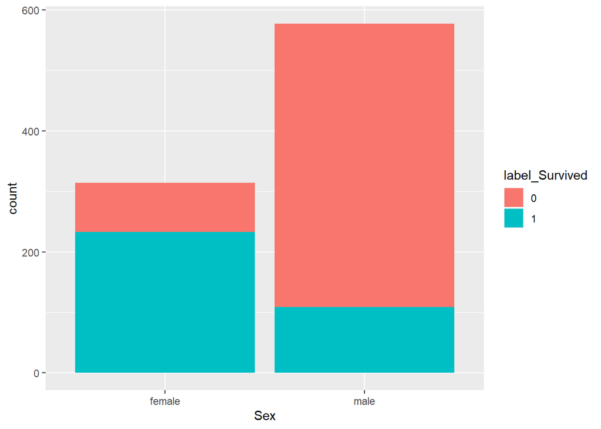

```r
LT<- dim(X)[1]

ggplot(data = X1[1:LT , ],aes(x=Sex,fill=label_Survived))+geom_bar()
```

This graph shows more female survived and less didn’t, and most of male didn’t survive and only almost half number of female, male survived.

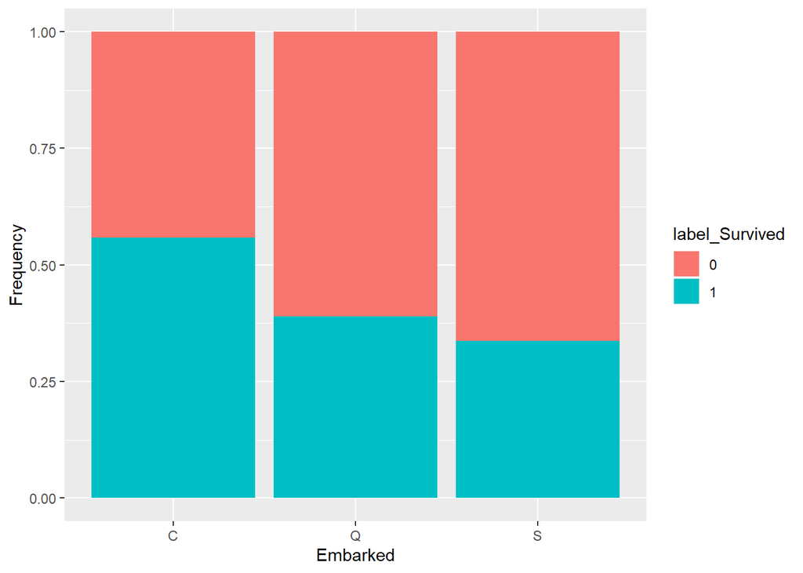

```r
ggplot(data = X1[1:LT,],aes(x=Embarked,fill=label_Survived))+geom_bar(position="fill")+ylab("Frequency")
```

Embarked is port of embarkation C represents Cherboug, Q=Queenstown, S for Southampton, here we can see that Survival rate was higher in C than Q and S.

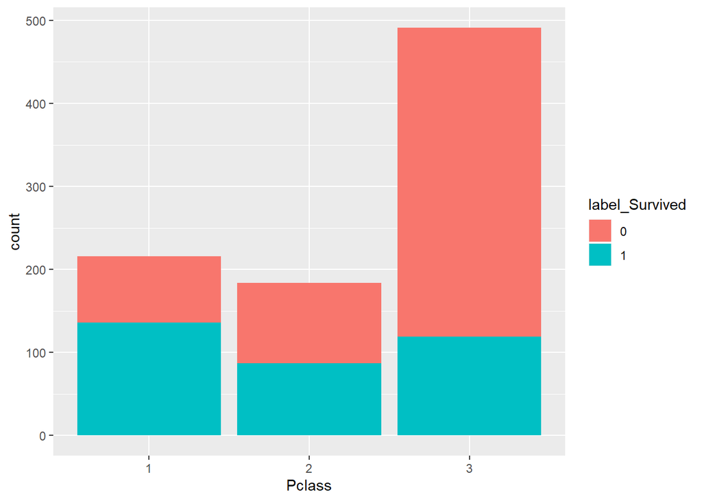

```r
ggplot(data = X1[1:LT,],aes(x=Pclass,fill=label_Survived))+geom_bar()
```

PClass is ticket class of passengers, 1st. 2nd, 3rd. It can be seen here that most deaths were in 3rd class and in 1st class more than half survived. In second class, half survived and half didn’t.

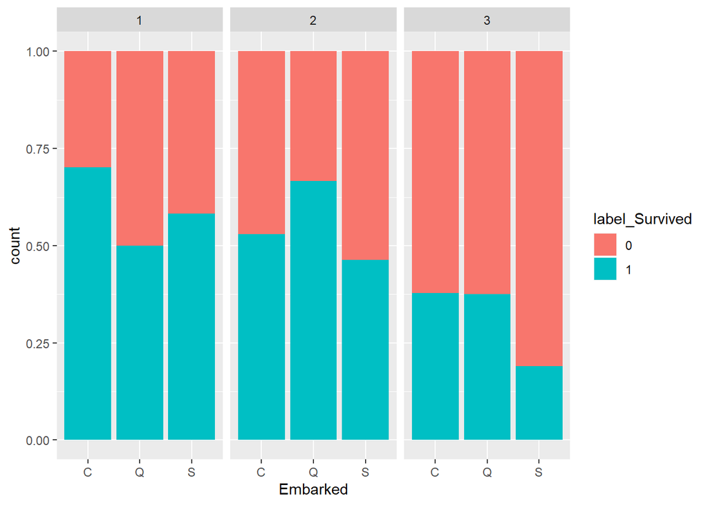

```r
ggplot(data = X1[1:LT,],aes(x=Embarked,fill=label_Survived))+geom_bar(position="fill")+facet_wrap(~Pclass)
```

This graph is a drill down of both of above graphs as It shows survival of passengers in Pclass with respect to the ticket class.

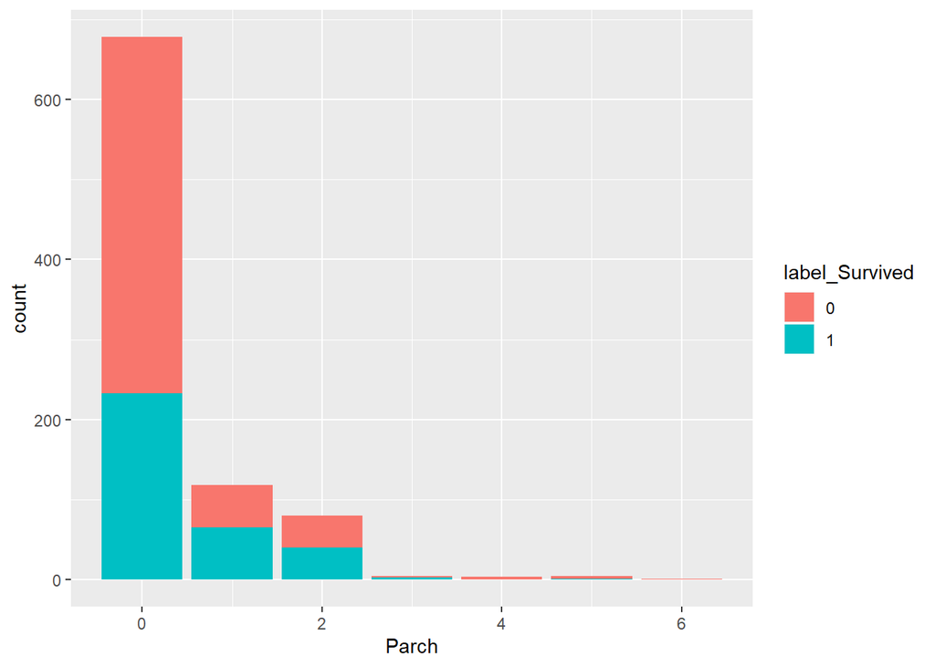

```r
ggplot(data = X1[1:LT,],aes(x=Parch,fill=label_Survived))+geom_bar()
```

Parch represents no. of people (parents or children of a passenger) onboard, most of the survival here is of people travelling alone, and most of died passengers were also alone, where as people with big family (>2) didn’t survive as much.

I choose 80 percent of data from overall dataset by using “sample” method and remaining data will be used to predict as testing my model. before doing this I have binded the label column with it as well so that after sample I get original corresponding class labels. 9 is choosing the label column and -9 is choosing rest of features.

```r
dataSet<- cbind(X1,label_Survived)

smp_size <- floor(0.80 * nrow(dataSet))

## set the seed to make your partition reproducible
set.seed(123)
train_ind <- sample(seq_len(nrow(dataSet)), size = smp_size)
train_y <- dataSet[train_ind, 9]
test_y <- dataSet[-train_ind, 9]

trainX <- dataSet[train_ind, -9]
testX <- dataSet[-train_ind, -9]
```

using random forest algorithm to train and predict.

```r
library(randomForest)
clf <- randomForest(train_y ~ . , data= trainX, ntree= 10)
```

```r
pred <- predict(clf, newdata=testX)
```

Confusion matrix to check accuracy, sensitvity, Specificity-> how well it our model is predicting

```r
library(caret)
confusionMatrix(test_y, pred)
```

```
## Confusion Matrix and Statistics
##
##           Reference
## Prediction  0  1
##          0 99 11
##          1 23 46
##
##                Accuracy : 0.8101
##                  95% CI : (0.7448, 0.8647)
##     No Information Rate : 0.6816
##     P-Value [Acc > NIR] : 8.306e-05
##
##                   Kappa : 0.5856
##
##  Mcnemar's Test P-Value : 0.05923
##
##             Sensitivity : 0.8115
##             Specificity : 0.8070
##          Pos Pred Value : 0.9000
##          Neg Pred Value : 0.6667
##              Prevalence : 0.6816
##          Detection Rate : 0.5531
##    Detection Prevalence : 0.6145
##       Balanced Accuracy : 0.8092
##
##        'Positive' Class : 0
##
```

model is 81% accurate.

```r
print(postResample(pred=pred, obs=test_y))
```

```
##  Accuracy     Kappa
## 0.8100559 0.5856481
```